# Machine Learning

## Indah Agustien Siradjuddin

## K-Means Clustering

Semester Gasal 2019-2020

## Definisi

1. Unsupervised Learning
2. Tujuan : mengelompokkan sejumlah *unlabeled data* berdasarkan kesamaan antara data tersebut

Berikut contoh *unlabeled data* (tanpa ada target)

[figure not shown]

dapat dikelompokkan menjadi dua buah grup/kelompok

[figure not shown]

atau dapat dikelompokkan menjadi empat buah grup/kelompok

[figure not shown]

## Implementasi

1. Pengolompokan user dari data social media
2. Sistem Rekomendasi

## K-Means Clustering dengan Scikit

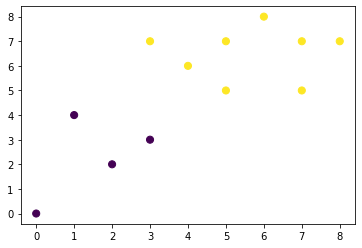

```python
from sklearn.cluster import KMeans
import numpy as np
import matplotlib.pyplot as plt
%matplotlib inline

data=np.array([[7,5],[5,7],[7,7],[3,3],[4,6],[1,4],[0,0],[2,2],[8,7],[6,8],[5,5],[3,7]])

est = KMeans(2)  # 2 clusters

est.fit(data)
y_kmeans = est.predict(data)

plt.scatter(data[:, 0], data[:, 1], c=y_kmeans,s=50);
```

```python
print(est.cluster_centers_)
print(y_kmeans)
```

```
[[1.5   2.25 ]
 [5.625 6.5  ]]
[1 1 1 0 1 0 0 0 1 1 1 1]
```

## Code - K-Means Clustering

```python
%matplotlib inline
import numpy as np
import matplotlib.pyplot as plt
```

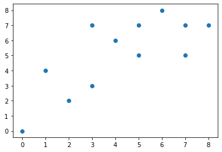

```python
data=np.array([[7,5],[5,7],[7,7],[3,3],[4,6],[1,4],[0,0],[2,2],[8,7],[6,8],[5,5],[3,7]])
centroid=np.array([[4,6],[5,5]],dtype=float)
numOfData=len(data)
plt.scatter(data[:, 0], data[:, 1])
```

```python
import kmeans
```

```python
data=np.array([[7,5],[5,7],[7,7],[3,3],[4,6],[1,4],[0,0],[2,2],[8,7],[6,8],[5,5],[3,7]])
centroid=np.array([[4,6],[5,5]],dtype=float)
dist=np.zeros((numOfData,2))
cluster=np.zeros(numOfData,dtype=int)
c=[[],[]]
centroid=kmeans.trainingKMeans(4,data,centroid)
```

```python
print(centroid)
```

```
[[5.625 6.5  ]
 [1.5   2.25 ]]
```

```
[0 0 0 1 0 1 1 1 0 0 0 0]
```

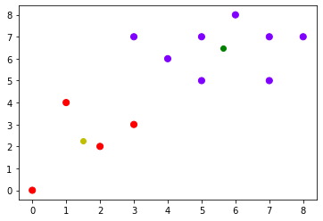

```python
#testing
cluster=np.zeros(numOfData,dtype=int)
data=np.array([[7,5],[5,7],[7,7],[3,3],[4,6],[1,4],[0,0],[2,2],[8,7],[6,8],[5,5],[3,7]])
for i in range (numOfData):
    dist[0,0]=np.linalg.norm(data[i]-centroid[0,:])
    dist[0,1]=np.linalg.norm(data[i]-centroid[1,:])
    cluster[i]=np.argmin(dist[0])
print(cluster)
plt.scatter(data[:, 0], data[:, 1], c=cluster,s=50,cmap='rainbow');
plt.plot(centroid[0,0],centroid[0,1],'go')
plt.plot(centroid[1,0],centroid[1,1],'yo')
plt.show()
```

Dataset:

[figure not shown]

Proses Pengelompokkan dengan epoch=3

epoch - 1

[figure not shown]

epoch - 2

[figure not shown]

epoch - 3

[figure not shown]

## Tantangan

Pemilihan *center cluster* pada inisialisasi sangatlah penting untuk data pelatihan. Jika *center cluster* tidak dipilih secara tepat, maka akan menimbulkan *local optimum*.

[figure not shown]

## Perhitungan Akurasi

Algoritma *K-means Clustering* adalah algoritma *unsupervised learning*, oleh karena itu *data training* adalah data pelatihan yang tidak memiliki target label, sehingga tidak dapat dibuat *confusion matrix*. Perhitungan akurasi dihitung dengan menggunakan **silhoutte coefficient**, dimana kinerja *clustering* dihitung berdasarkan *compactness* and *separation* dari sebuah *cluster*.

\begin{eqnarray} s=\frac{b-a}{max(a,b)} \end{eqnarray}

dimana  
a= rata-rata jarak antara data dengan data lain di dalam *cluster* yang sama  
b= rata-rata jarak antara data dengan data lain dari *cluster* yang terdekat

## Silhoutte Coefficient dengan Scikit

```
score= 0.7591876061783829
[1 1 0 0]
```

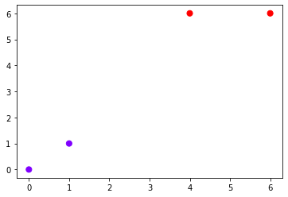

```python
from sklearn.cluster import KMeans
from sklearn import metrics


data=np.array([[6,6],[4,6],[1,1],[0,0]])
centroid=np.array([[4,6],[0,0]],dtype=float)

est = KMeans(2)  # 2 clusters
est.fit(data)
y_kmeans = est.predict(data)
plt.scatter(data[:, 0], data[:, 1], c=y_kmeans,s=50,  cmap='rainbow');
print('score=', metrics.silhouette_score(data, est.labels_,metric='euclidean'))

print(y_kmeans)
```

## Code : Silhoutte Coefficient

```python
# assume that data is clustered
a=np.linalg.norm(data[0,:]-data[1,:])
b1=np.linalg.norm(data[0,:]-data[2,:])
b2=np.linalg.norm(data[0,:]-data[3,:])
b=(b1+b2)/2
print(a,b1,b2,b)

coef=(b-a)/np.maximum(a,b)
print(coef)
```

```
2.0 7.0710678118654755 8.48528137423857 7.7781745930520225
0.74287026138671
```